# Project-2

Hannes Gubler

21 May, 2023

# 1 Introduction

In this report, we work with online shopping data where one observation corresponds to sessions, i.e. instances of a user visiting an e-commerce website. These sessions take some time and may or may not lead to a purchase. Our objective is to predict whether a user session is likely to result in a purchase or not. This prediction can be utilized by the website owner to display targeted advertisements to possibly generate more sales. To predict the outcome of a session will fit a logistic regression model for the binary response variable `purchase`, where we have 17 predictors available.

The outline of the remainder of this project is as follows: We start by graphically exploring and wrangling the data. After that we use the prepared data to build a logistic regression model. Finally, we evaluate the performance of our final model using the Area Under Curve (AUC) criterion.

# 2 Data Exploration

As mentioned, we have 17 predictors available to build a model for the binary response `purchase`. These predictors, displayed below, give information about the user’s session.

- `administrative` Number of administrative-type pages that the user visited.
- `administrative_duration` Time spent on administrative pages.
- `informational` Number of informational-type pages visited.
- `informational_duration` Time spent on informational-type pages.
- `product_related` Number of product-related-type pages visited.
- `product_related_duration` Time spent on product-related-type pages.
- `bounce_rates` Average bounce rate of pages visited (for a specific webpage. the bounce rate is the percentage of users who enter and leave the webpage without triggering any request during their sessions).
- `exit_rates` Average exit rate of pages visited (for a specific webpage, the exit rate is the proportion of page views to the page that were last in the session).
- `page_values` Average page value of pages visited (for a specific webpage, the page value gives an idea of how much each page contributes to the site’ revenue).
- `special_day` Value in [0, 1] indicating closeness of the session to a special day (e.g. Mother’s day, etc.).
- `month` Which month the session took place.
- `operating_systems` Operating systems of the users coded as integers.
- `browser` Web browsers of the users coded as integers.
- `region` Geographic region in which the user is located coded as integers.
- `traffic_type` Where from the user arrived at the site (e.g. ad banner, SMS link, direct URL, etc.) coded as integers.
- `visitor_type` Self explanator, e.g. returning or new visitor to the webpage.
- `weekend` Binary indicator of whether the session took place during a weekend.

The next step is to decide which variables we include as factors in the model. For our model, we use `month`, `operating_systems`, `browser`, `region`, `traffic_type`, `visitor_type` and `weekend` as factors, while the remaining predictors are treated as numeric variables.

In Figure (2.1), we graphically explore our variables by looking at the histograms.

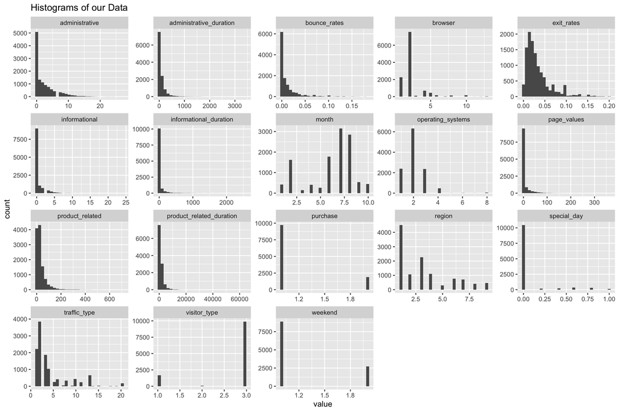

Figure 2.1: Histograms of all the variables in our dataset.

We see that some variables that we treat as factors have some levels with very few observations (e.g the factors `operating_systems` or `browser`). Levels with a small number of observations can be problematic because the model fits a single parameter for these levels which will have high variance due to the small number of datapoints. Therefore we merge small levels (less than 40 observations) within one factor variable into a new level called “others”.

For the numerical variables, we observe in Figure (2.1) that a lot of them have a right scewed distribution, so we could log transform them to have more evenly spread out values. However they all have a lot of zero values so we rather take the square root of those variables, since it has a similar effect as the logarithm. (Another possibility would be to add one to every observation before taking the log, but we decide to go for the “simpler” transformation of taking the square root). Namely, we transform the numerical variables `administrative` `administrative_duration`, `bounce_rates`, `exit_rates`, `informational`, `informational_duration`, `page_values`, `product_related` and `product_related_duration` by applying the square root.

Now we are ready to build our first models in Section (3).

# 3 Logistic Regression Model Building

In this Section we build a logistic regression model to predict the response `purchase.` To compare two different models, we use Anova tables with the likelihood ratio test (which follows a Chi-squared distribution asymptotically), as well as the area under the curve (AUC) and the BIC criterion.

For a starting point, we fit a logistic model including all the predictors available in the data that we prepared in the Section before. After that we look at the Type II Anova table. Type II Anova compares, for each predictor, the full model with the model excluding that specific predictor by a likelihood ratio test.

Table 3.1: Type II Anova table for a logistic regression model including all predictors from the data. For each predictor, the full model is compared to the model with all variables except that specific predictor by a likelihood ratio test.

|  | LR Chisq | Df | Pr(>Chisq) |
| --- | --- | --- | --- |
| administrative | 1.194 | 1 | 0.275 |
| administrative_duration | 0.745 | 1 | 0.388 |
| informational | 1.513 | 1 | 0.219 |
| informational_duration | 0.311 | 1 | 0.577 |
| product_related | 0.746 | 1 | 0.388 |
| product_related_duration | 10.255 | 1 | 0.001 |
| bounce_rates | 9.562 | 1 | 0.002 |
| exit_rates | 4.596 | 1 | 0.032 |
| page_values | 2782.727 | 1 | 0.000 |
| special_day | 0.010 | 1 | 0.921 |
| month | 223.932 | 9 | 0.000 |
| operating_systems | 5.632 | 5 | 0.344 |
| browser | 13.041 | 10 | 0.221 |
| region | 8.005 | 8 | 0.433 |
| traffic_type | 38.629 | 12 | 0.000 |
| visitor_type | 19.606 | 2 | 0.000 |
| weekend | 1.749 | 1 | 0.186 |

The type II Anova table suggests us that the predictors `product_related_duration`, `bounce_rates`, `exit_rates`, `page_vales`, `month`, `traffic_type` and `visitor_type` are significant at level 0.05. So we fit a model containing only these predictors, which is a submodel of the model containing all predictors. But we still need to examine this submodel because we could run into multiple testing issues by using only significant variables in Table (3.1), as we calculated 17 different p-values. So we compare the full model with the sub-model by an Anova model-submodel test, the AUC and BIC.

Table 3.2: Anova Model-Submodel test as well as AUC and BIC to test the model containing only the significant variables from table (3.1) vs the model containing all the variables.

|  | Resid. Df | Resid. Dev | Df | Deviance | Pr(>Chi) | AUC | BIC |
| --- | --- | --- | --- | --- | --- | --- | --- |
| Submodel | 11602 | 6302.001 | NA | NA | NA | 0.911 | 6564.119 |
| Full model | 11572 | 6264.350 | 30 | 37.651 | 0.159 | 0.908 | 6807.308 |

All these results support the submodel as it has a higher AUC, lower BIC and the Anova model-submodel test suggests to not reject the null hypothesis (submodel) at a level 0.05.

So we proceed with the submodel from above and analyze its residuals in Figure (3.1) by plotting the residuals vs each predictor and adding a smoother to the plots (except for `visitor_type` which only takes 3 values).

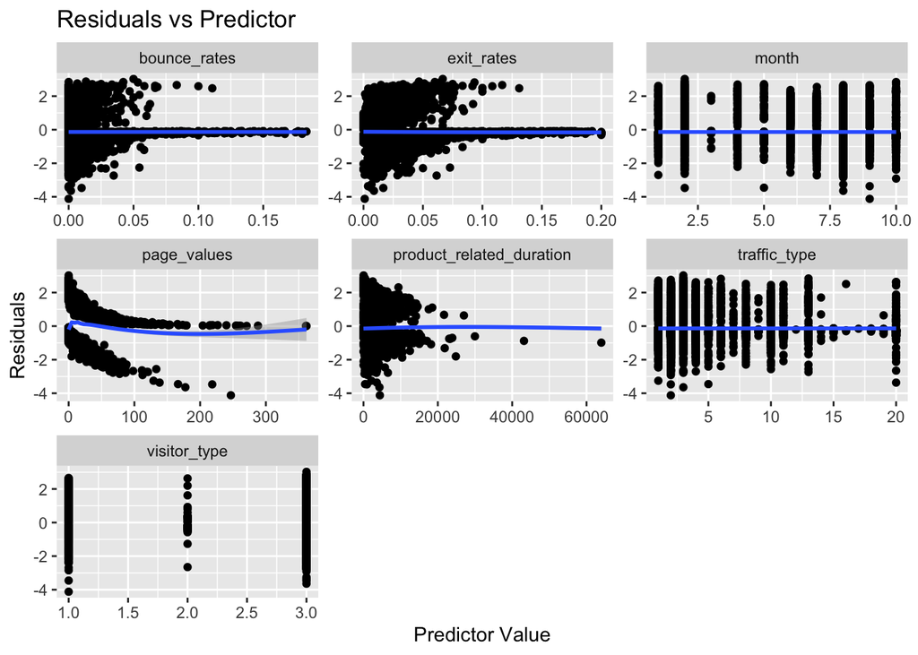

Figure 3.1: Residuals vs predictor plot with a smoother. The residuals come from a logistic regression model using only the variables that were selected by the type II Anova table.

First note that the residuals are often organized in two clouds since the response variable is binary, so it is useful to use a smoother to detect patterns. Also, it looks like we could have a quadratic dependency on `page_values`. So we fit a model containing all predictors from the current model together with a quadratic dependency on `page_values`. We then compare the models with and without quadratic dependency on `page_values` with an Anova model-submodel test, AUC and BIC.

Table 3.3: Anova Model-Submodel test as well as AUC and BIC to test if we should include a quadratic dependency on page_values in our model.

|  | Resid. Df | Resid. Dev | Df | Deviance | Pr(>Chi) | AUC | BIC |
| --- | --- | --- | --- | --- | --- | --- | --- |
| Model without quadratic dependence | 11602 | 6302.001 | NA | NA | NA | 0.911 | 6564.119 |
| Model with quadratic dependence | 11601 | 6088.821 | 1 | 213.18 | 0 | 0.913 | 6360.300 |

The Anova test together with AIC and BIC suggest us to keep the quadratic dependency on `page_values`, so we proceed with this model. In Figure (3.2) we verify if the residuals plot for the predictor `page_value` now looks better.

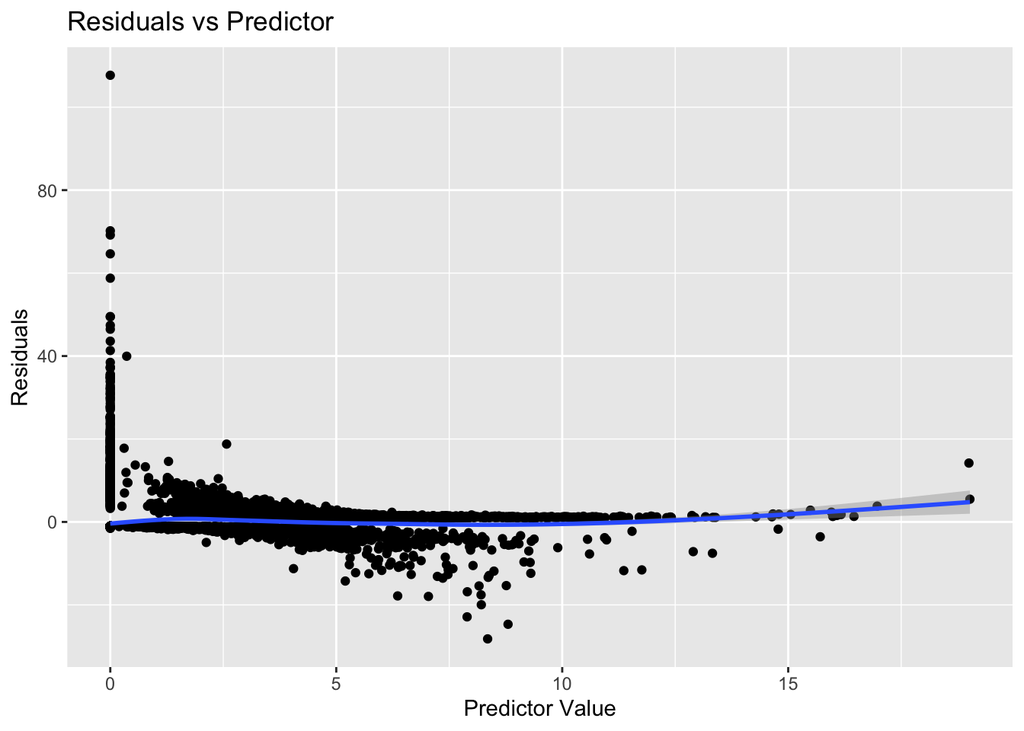

Figure 3.2: Residuals vs the predictor page_values after including a quadratic dependency on page_values into the model.

The residuals plot already looks better but we can still observe some slight non-linearity. So we add a cubic term of `page_values` to the model. As before, we use the model-submodel Anova test together with the AUC and BIC to compare the model with cubic dependency on `page_values` with the model from before without cubic dependency on page_values (but still including quadratic dependency on `page_values`).

Table 3.4: Anova Model-Submodel test as well as AUC and BIC to test if we should include a cubic dependency on page_values in our model.

|  | Resid. Df | Resid. Dev | Df | Deviance | Pr(>Chi) | AUC | BIC |
| --- | --- | --- | --- | --- | --- | --- | --- |
| Model without cubic dependence | 11601 | 6088.821 | NA | NA | NA | 0.913 | 6360.300 |
| Model with cubic dependence | 11600 | 6025.370 | 1 | 63.451 | 0 | 0.914 | 6306.211 |

Again, the Anova table, AUC and BIC suggest us to keep the cubic dependency on `page_values`. We will not add any more higher order terms of `page_values` to the model for two reasons: First, we should not over interpret the residuals plots for the logistic regression (since the FWL theorem does not hold) and secondly, adding too many terms of higher order could lead to an overfit of the data.

We now have a relatively simple model with a good performance when we compare to the full model we had at the start. Our last step will be to look for potential interactions in Section (3.1).

## 3.1 Testing for Interactions

Table 3.5: Anova Model-Submodel test as well as AUC and BIC to test if we should include interaction terms between bounce_rate and page_values (and its higher order terms) in our model.

|  | Resid. Df | Resid. Dev | Df | Deviance | Pr(>Chi) | AUC | BIC |
| --- | --- | --- | --- | --- | --- | --- | --- |
| Model without interaction | 11600 | 6025.370 | NA | NA | NA | 0.914 | 6306.211 |
| Model with interaction | 11597 | 5961.659 | 3 | 63.711 | 0 | 0.918 | 6270.584 |

All three criterions suggest to keep the model with the interactions. We take this as our final model as we have reached a good AUC and adding more terms would make the model even more complex as it is already. So we report a final AUC of 0.918.

## 3.2 Final model

As described in the section before, in our final model we use `product_related_duration`, `bounce_rates`, `exit_rates`, `month`, `traffic_type` and `visitor_type`, `page_vales` (with quadratic cubic dependency) as well as an interaction between `bounce_rates` and `page_values` (and its quadratic and cubic dependencies) as predictors. The final coefficients are the following.

Table 3.6: Coeficients of the final logistic regression model.

| Coefficient name | Coeficient value |
| --- | --- |
| (Intercept) | -2.575 |
| product_related_duration | 0.006 |
| bounce_rates | 0.106 |
| exit_rates | -1.445 |
| page_values | 1.457 |
| page_values$^2$ | -0.148 |
| page_values$^3$ | 0.005 |
| monthDec | -0.615 |
| monthFeb | -1.402 |
| monthJul | 0.081 |
| monthJune | -0.343 |
| monthMar | -0.562 |
| monthMay | -0.747 |
| monthNov | 0.670 |
| monthOct | -0.167 |
| monthSep | -0.016 |
| traffic_type2 | 0.250 |
| traffic_type3 | -0.080 |
| traffic_type4 | 0.134 |
| traffic_type5 | 0.405 |
| traffic_type6 | -0.067 |
| traffic_type7 | 0.135 |
| traffic_type8 | 0.708 |
| traffic_typeother | 0.147 |
| traffic_type10 | 0.449 |
| traffic_type11 | 0.575 |
| traffic_type13 | -0.482 |
| traffic_type20 | 0.609 |
| visitor_typeOther | -0.477 |
| visitor_typeReturning_Visitor | -0.615 |
| bounce_rates:page_values | -0.070 |
| bounce_rates:page_values$^2$ | -0.408 |
| bounce_rates:page_values$^3$ | 0.023 |

In the following paragraph we provide some examples on how to interpret these coefficients.

If we look at the month November, the odds ratio between an observation November and an observation from August (base level of the month variable), all other predictors being equal, is given by $e^{0.670} \approx 1.954$ according to our model. Interestingly for the month December, the odds ratio between an observation from December and August, all other predictors being equal, is $e^{-0.615} \approx 0.541$. Hence our model suggests that it is more likely for a user in August than a user in December to carry out a purchase. A possible reason for this is that in December, where a lot of users may look for Christmas gifts, people visit a lot of different webpages to search for a good gift but only on one webpage a purchase will be made So for a specific webpage, the probability of a user completing a purchase on that website in December could be lower than usual.

# 4 Conclusion

It is a hard task to build a statistical model when a dataset with a lot of variables is available, since there is a huge number of possible different combinations, transformations and interactions between variables. In this report, we carried out a procedure to build such a model with statistical reasoning, however a different dataset can require a different procedure. With the Anova test, AUC and BIC we used three useful tools do compare two different models. It is always good to evaluate a model according to multiple criterions and in our case, they always suggested the same decision. If this was not the case however one needs to build the model around one criterion, depending on the objective. In our case, this would have been the AUC, which evaluates the predictive power of a model.

In general, it would have been very helpful to have some deeper knowledge about the domain of online shopping data, since this would give some intuition on what variables are important or what transformations/interactions could have been useful.